# Generalized Additive Models

###### Résidus

- C’est la fonction *‘gam.check()’* qui permet notamment la visualisation de la distribution des résidus pour la vérification des hypothèses d’indépendance et de distribution avec: la droite de Henry, l’histogramme de distribution et le nuage de points des résidus. On voit alors que nos résidus ne sont pas optimaux, mais restent acceptables et nous conforte dans notre choix dans l’hypothèse d’une distribution normal des résidus. De plus, la loi de Poisson s’applique généralement aux phénomènes accidentels où la probabilité p est très faible, ou aux phénomènes sans mémoires ce qui n’est pas notre cas ici. Sur la droite de Henry (QQ plot) on voit que les observations sont globalement alignées sur la droite exceptée quelques-unes en haut à droite du graphique, observations que l’on retrouve en dehors de la ligne à 0 sur le graphique ‘Resids vs. linear pred’ (cf. bulles de la tortue) ainsi que sur le graphique opposant les valeurs prédites aux valeurs observées. On constate aussi 2 groupes principaux dans les résidus, liés au fait que les durées des jobs en journée soient autour de 10/20 secondes puis autour de 40/50 secondes une fois chaque journée.
- La fonction *‘gam.check()’* nous permet aussi de vérifier si le paramètre de lissage *k* a été fixé correctement. Pour cela nous devons regarder si *k* est significativement supérieur aux *edf* (“Effective Degrees of Freedom”). Dans notre cas, la p-value est trop faible se qui peut signifier que le nombre de fonctions de bases k est trop faible, particulièrement quand l’edf est proche de k’.

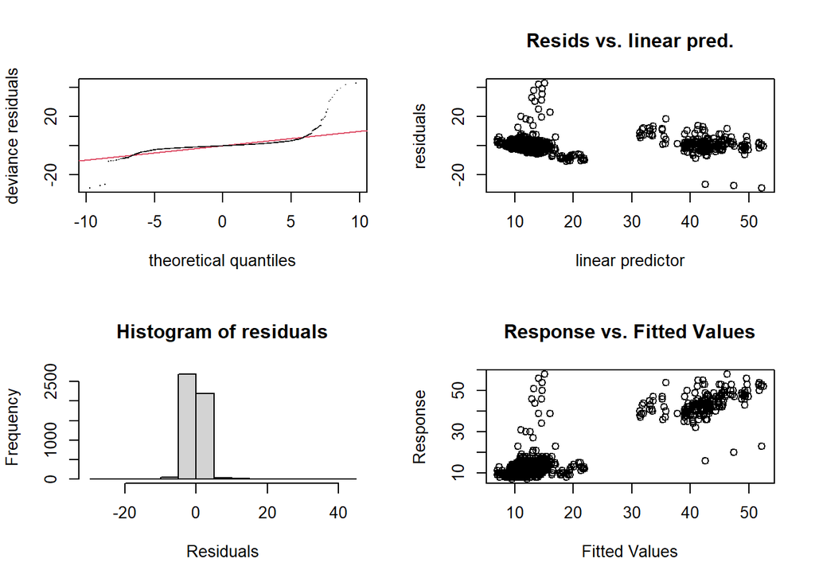

```r
# Résidus meilleur modèle
par(mfrow=c(2,2))
gam.check(gam4_ID1)
##
## Method: GCV   Optimizer: magic
## Smoothing parameter selection converged after 20 iterations.
## The RMS GCV score gradient at convergence was 2.52454e-05 .
## The Hessian was positive definite.
## Model rank =  701 / 701
##
## Basis dimension (k) checking results. Low p-value (k-index<1) may
## indicate that k is too low, especially if edf is close to k'.
##
##                   k'    edf k-index p-value
## s(Day)          6.00   3.54    1.06   1.000
## te(Week,Hour) 689.00 407.03    0.93   0.045 *
## ---
## Signif. codes:  0 '***' 0.001 '**' 0.01 '*' 0.05 '.' 0.1 ' ' 1
```

```r
concurvity(gam4_ID1)
##               para    s(Day) te(Week,Hour)
## worst    0.9780102 0.6595535  5.912765e+28
## observed 0.9780102 0.3857351  2.750745e-03
## estimate 0.9780102 0.3729913  2.039991e-05
```

- Ce plot en 3D permet de voir comment les heures de la journée et les semaines de l’année affectent la durée des requêtes Stitch et donc noter certaines patterns. On retrouve le temps élevé d’éxécution des *jobs* prédit en début de journée puis quelques fluctuations avec notamment des hausses de la durée autour de 6h ainsi que 15h. Rappelons que les valeurs de la variable ‘Week’ vont de 40 à 52 puis de 1 à 18 donc on retrouve un vide entre ces 2 périodes et quelques fluctuations en fin d’année 2019 et début d’année 2020. On ne trouve pas vraiment de comportement régulier pour la variable ‘Week’. Par ailleurs, les données étant relativement différentes d’une connection ID à l’autre nous devrons réitérer le processus pour chaque chronique.

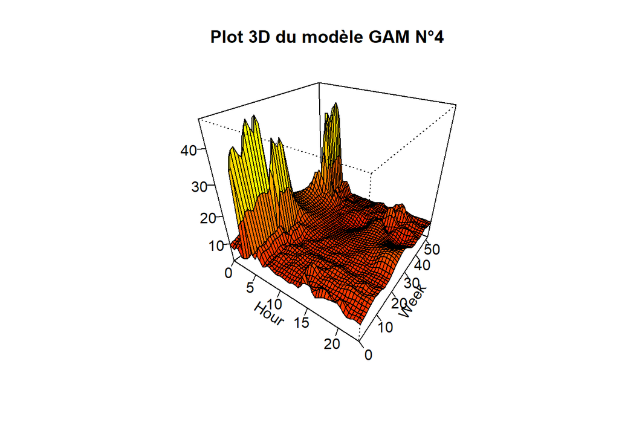

```r
# Plot 3D des valeurs de Y prédites par le GAM final
library(mgcv)
  # on remodélise en ne prenant que 2 arguments pour faire un graphique 3D
gam_Vis <- gam(JOB_DURATION ~ te(Hour, Week, k=c(24,30), bs = c("cc", "ps")), data = df_ID1, family = gaussian)
  # visualisation 3D
vis.gam(gam_Vis, n.grid = 50, theta = 35, phi = 32, zlab = "",
        ticktype = "detailed", color = "heat", main = "Plot 3D du modèle GAM N°4")
```

###### Autocorrélation

Afin de valider les modèles GAM, les résidus doivent être indépendants et identiquement distribués (iid). Dans le cas des séries temporelles, c’est une hypothèse très forte sur les résidus qui n’est bien évidemment pas respectée en général. Les valeurs des séries temporelles actuelles sont fortement corrélées aux valeurs passées, de sorte que les erreurs du modèle seront également corrélées, c’est ce que l’on appelle le phénomène d’**autocorrélation**. Cela implique que les coefficients de régression et les résidus estimés d’un modèle peuvent être biaisés. Pour résoudre ce problème, nous pouvons le faire en incluant un processus autorégressif (AR) pour capter l’autocorrélation des erreurs de notre modèle. Nous allons utiliser la fonction *gamm()* du package `mgcv` pour réaliser cette nouvelle modélisation du GAM.4 mais cette fois-ci en prenant en compte le phénomène d’autocorrélation.

```r
gam4_ar0 <- gamm(JOB_DURATION ~ TAP_VERSION + s(Day, k=7, bs="cp") + te(Week, Hour, k=c(30,24), bs = c("ps", "cc")),
                data = df_ID1,
                method = "REML")

gam4_ar1 <- gamm(JOB_DURATION ~ TAP_VERSION + s(Day, k=7, bs="cp") + te(Week, Hour, k=c(30,24), bs = c("ps", "cc")),
                data = df_ID1,
                correlation = corARMA(form = ~ 1|Week, p = 1),
                method = "REML")
```

Nous pouvons comparer les modélisations, sans et avec prise en compte de l’autocorrélation des résidus avec une ANOVA qui sélectionne le meilleur modèle sur la base du log de vraisemblance généralisé. Les résultats du test ci-dessous nous confirment qu’il était judicieux d’estimer en prenant en compte une possible autocorrélation des résidus de la variable ‘Week’. Cela se voit grâce au BIC inferieur pour le gam4_ar1 ainsi que la p-value significative dans la comparaison des 2 modèles.

```r
anova(gam4_ar0$lme, gam4_ar1$lme)
##              Model df      AIC      BIC    logLik   Test  L.Ratio p-value
## gam4_ar0$lme     1 11 25382.95 25454.60 -12680.47
## gam4_ar1$lme     2 12 25363.18 25441.35 -12669.59 1 vs 2 21.76292  <.0001
```

Afin d’observer l’autocorrélation partielle des résidus normalisés il est possible de réaliser le plot suivant :

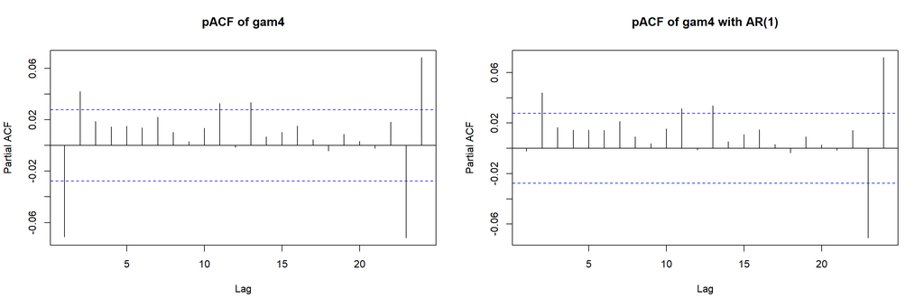

Ces graphiques nous donnent les corrélations partielles des résidus avec ses propres valeurs laguées. Les valeurs optimales du pACF se trouvent normalement en dessous des lignes en pointillé ce qui n’est pas vraiment le cas ici, même pour le modèle gam4_ar1. Nous allons donc tenter d’améliorer cela.

Pour choisir les paramètres optimaux du nombre de retards à inclure dans le processus autorégressif sur les résidus, il est possible de passer par la fonction *auto.arima* du package `forecast`. Cette fonction choisira le meilleur nombre de retards sur la base de l’AIC. Le code suivant permet de faire cela.

```r
library(forecast)
arma_res <- auto.arima(resid(gam4_ar0$lme, type = "normalized"),
                       stationary = TRUE, seasonal = FALSE)
arma_res$coef
##         ar1         ma1         ma2         ma3
##  0.92607777 -0.99713982  0.11062114 -0.02357678
```

D’après la fonction *auto.arima*, il serait plus pertinent d’appliquer un ARMA(1,3) sur les résidus pour résoudre au mieux l’autocorrélation. Nous devrions vérifier cela en réestimant le modèle et comparant les autocorrélations partielles entre **gam4_ar1** et **gam4_arma13**, mais étant donné le temps conséquent d’exécution, nous avons décidé de présenter les codes sans les exécuter.

```r
#gam4_arma13 <- gamm(JOB_DURATION ~ TAP_VERSION + s(Day, k=7, bs="cp") + te(Week, Hour, k=c(30,24), bs = c("ps", "cc")),
#                data = df_ID1,
#                correlation = corARMA(form = ~ 1|Week, p = 1, q = 3),
#                method = "fREML")

#anova(gam4_ar1$lme, gam4_arma13$lme)

#layout(matrix(1:2, ncol = 2))
#pacf(resid(gam4_ar1$lme, type = "normalized"), lag.max = 48, main = "pACF of gam4 with AR(1)")
#pacf(resid(gam4_arma13$lme, type = "normalized"), lag.max = 48, main = "pACF of gam4 with ARMA(1,3)")
```

#### ID 2

##### 1er GAM

Nous démarrons les modélisations pour la chronique n°2 avec un modèle GAM basique où nous laissons le modèle ajuster ses paramètres seul, c’est à dire avec la méthode “REML”. Pour rappel les connections ID égales à 2 sont observées l’été 2019, la variable ‘TAP_VERSION’ prend seulement 2 valeurs (‘1.4.33’ pour 2366 observations et ‘1.4.34’ pour les restantes). Pour cette sous-base de la chronique n°2 la valeur des heures considère aussi les minutes que nous avons codées comme étant les décimales après la virgule pour pouvoir passer la variable en quantitative précédemment. Dans un premier modèle généralisé nous incluons donc la variable ‘TAP_VERSION’ bien qu’elle ne prenne que 2 valeurs nous supposons qu’elle ne sera pas significative mais cherchons à en être sûrs pour ne pas passer à côté d’une éventuelle information. Nous ajoutons aussi des fonctions des variables ‘Week’, ‘Day’ et ‘Hour’.

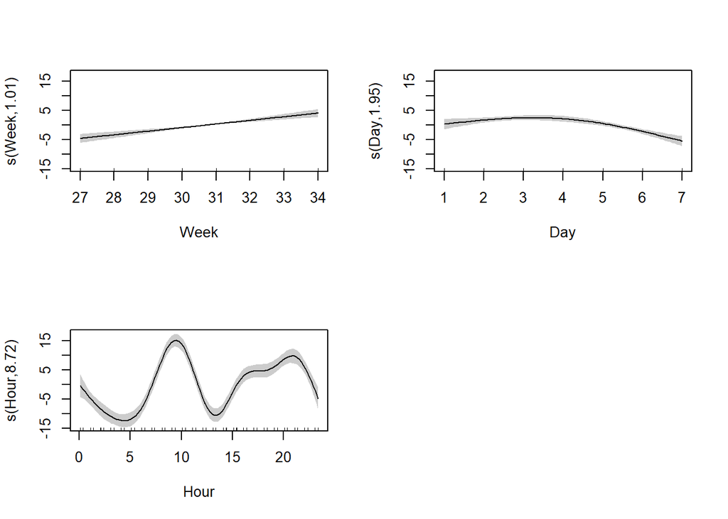

```r
# On estime un premier modèle gam le plus simple possible c-à-d. sans rien définir
gam1_ID2 <- gam(formula=JOB_DURATION ~ TAP_VERSION + s(Week, k=1) + s(Day, k=1) + s(Hour), data = df_ID2, method="REML")
summary(gam1_ID2)  #R2=0.164
##
## Family: gaussian
## Link function: identity
##
## Formula:
## JOB_DURATION ~ TAP_VERSION + s(Week, k = 1) + s(Day, k = 1) +
##     s(Hour)
##
## Parametric coefficients:
##                   Estimate Std. Error t value Pr(>|t|)
## (Intercept)        178.204      0.419 425.309   <2e-16 ***
## TAP_VERSION1.4.34   -1.626      2.014  -0.807     0.42
## ---
## Signif. codes:  0 '***' 0.001 '**' 0.01 '*' 0.05 '.' 0.1 ' ' 1
##
## Approximate significance of smooth terms:
##           edf Ref.df     F p-value
## s(Week) 1.010  1.020 36.42  <2e-16 ***
## s(Day)  1.951  1.998 20.89  <2e-16 ***
## s(Hour) 8.721  8.977 45.47  <2e-16 ***
## ---
## Signif. codes:  0 '***' 0.001 '**' 0.01 '*' 0.05 '.' 0.1 ' ' 1
##
## R-sq.(adj) =  0.164   Deviance explained = 16.8%
## -REML =  11072  Scale est. = 410.5     n = 2497
plot(gam1_ID2,residuals=FALSE, shade=TRUE, pages=1)
```

On voit d’emblée que la variable ‘TAP_VERSION’ n’est pas significative comme nous l’avons supposé précédemment, mais toutes les fonctions incluses elles le sont. De plus, on remarque que l’évolution des variables de semaine et de jours est inverse par rapport aux estimations de l’ID1. La variable ‘Week’ qui était incurvée est désormais parfaitement linéaire (mais on observe tout de même que les semaines fin août ont un temps d’éxécution plus long que les semaines début juillet avec une hausse linéaire) et celle des jours ‘Day’ est maintenant légèrement concave. Leurs degrés de liberté estimés confirment cela car ils sont proches de 1, nous garderons donc pour les estimations suivantes que les variables ‘Day’ et ‘Hour’. Concernant cette dernière on voit que les temps des jobs ne suivent pas les mêmes évolutions dans une journée que l’ID1, ce que nous avions pu noter dès la visualisation des données dans une partie antérieure, et l’on voit que le pic est désormais autour de 9-10h du matin et que l’après-midi les temps augmentent à nouveau pour diminuer en fin de journée. Finalement, on voit que la qualité d’ajustement du modèle est vraiment faible (-20 points par rapport aux GAM de la chronique une) ; le $R^2$ est de 16.4% pour ce premier modèle, nous cherchons à augmenter le plus possible cette qualité et résumerons notre recherche en un tableau récapitulatif.

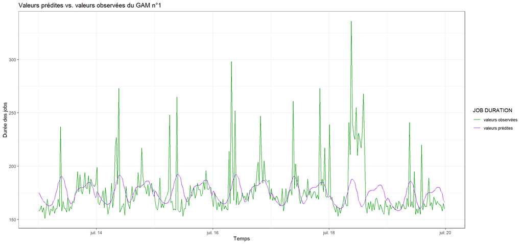

```r
# On plote les valeurs prédites et les valeurs observées pour voir la qualité du modèle simple
fitted <- gam1_ID2$fitted.values
real_ID2 <- df_ID2$JOB_DURATION
date_ID2 <- df_ID2[,2]

prev <- cbind(date_ID2, real_ID2, fitted)
prev <- data.frame(prev)
prev1 <- prev[222:557,]

ggplot(data=prev[222:557,])+
  geom_line(mapping=aes(y=real_ID2,x= START_TIME,color="valeurs observées")) +
  geom_line(mapping=aes(y=fitted,x= START_TIME,color="valeurs prédites")) +
  theme_bw() +
  scale_color_manual(values = c(
    'valeurs prédites' = "purple",
    'valeurs observées' = "#009900")) +
  labs(color = 'JOB DURATION', x = "Temps", y = "Durée des jobs",
       title = "Valeurs prédites vs. valeurs observées du GAM n°1")
```

Visuellement la précision faible de nos prédictions se confirme avec une courbe des valeurs prédites par le modèle qui ne suit pas les évolutions des valeurs réelles et capte très mal le pic de la matinée à 9h09.

##### Comparaison des modèles

###### Optimisation

```r
# Calcul du MAPE pour chacun des modèles
MAPE_gam1_ID2 <- mean(abs((df_ID2$JOB_DURATION-gam1_ID2$fitted.values)/df_ID2$JOB_DURATION))
MAPE_gam2_ID2 <- mean(abs((df_ID2$JOB_DURATION-gam2_ID2$fitted.values)/df_ID2$JOB_DURATION))
MAPE_gam3.1_ID2 <- mean(abs((df_ID2$JOB_DURATION-gam3.1_ID2$fitted.values)/df_ID2$JOB_DURATION))
MAPE_gam3.2_ID2 <- mean(abs((df_ID2$JOB_DURATION-gam3.2_ID2$fitted.values)/df_ID2$JOB_DURATION))
MAPE_gam3.3_ID2 <- mean(abs((df_ID2$JOB_DURATION-gam3.3_ID2$fitted.values)/df_ID2$JOB_DURATION))
MAPE_gam3.4_ID2 <- mean(abs((df_ID2$JOB_DURATION-gam3.4_ID2$fitted.values)/df_ID2$JOB_DURATION))
MAPE_gam3.5_ID2 <- mean(abs((df_ID2$JOB_DURATION-gam3.5_ID2$fitted.values)/df_ID2$JOB_DURATION))

# --- Tableau récapitulatif des modèles éstimés ---
recap_modele_ID2 <- data.frame(GAM.1 = c("TAP_VERSION", "s(Week,k=1)", "s(Day,k=1)", "s(Hour)", "3/4", 0.164, "/", round(gam1_ID2$aic,2), round(MAPE_gam1_ID2,4), "X"),
                               GAM.2 = c("s(Day,k=7)", "s(Hour,k=48)", "", "", "2/2", 0.3576, 321.82, round(gam2_ID2$aic,2), round(MAPE_gam2_ID2,4),"Ok"),
                               GAM.3.1 = c("te(Day,Hour,k=c(7,48))", "", "", "", "1/1", 0.3779, 317.5, round(gam3.1_ID2$aic,2), round(MAPE_gam3.1_ID2,4),"Ok"),
                               GAM.3.2 = c("te(Week,Hour,k=c(7,48))", "", "", "", "1/1", 0.3742, 317.82, round(gam3.2_ID2$aic,2), round(MAPE_gam3.2_ID2,4),"Ok"),
                               GAM.3.3 = c("te(Day,Hour,k=c(7,48)", "", "", "", "1/1", 0.3722, 319.8, round(gam3.3_ID2$aic,2), round(MAPE_gam3.3_ID2,4),"Ok"),
                               GAM.3.4 = c("te(Day,Hour,k=c(7,48))", "te(Week,Hour,k=c(7,48))", "", "", "2/2", 0.4204, 302.04, round(gam3.4_ID2$aic,2), round(MAPE_gam3.4_ID2,4),"Ok"),
                               GAM.3.5 = c("te(Day,Hour,k=c(7,48))", "te(Week,Hour,k=c(7,48))", "te(Week,Day,k=c(7,7))", "", "3/3",  0.4313, 296.87, round(gam3.5_ID2$aic,2), round(MAPE_gam3.5_ID2,4),"Ok"))

row.names(recap_modele_ID2) <- c("1er terme",  "2è terme",  "3è terme",  "4è terme",  "Nombre de termes significatifs", "R2", "GCV", "AIC", "MAPE", "Validation")

kbl(recap_modele_ID2, caption="Tableau récapitulatif des modèles éstimés pour l'ID 2") %>% kable_classic(full_width = F, html_font = "Cambria") %>% column_spec(1, bold=T) %>% column_spec(8, color = 'green') %>% add_header_above(c(" " = 1, "Effets univariés seulement" = 2, "Effets bivariés" = 5), italic=T) %>% pack_rows("Termes inclus dans le modèle", 1, 4) %>% kable_styling(font_size = 9)
```

Tableau récapitulatif des modèles éstimés pour l’ID 2

|  | Effets univariés seulement GAM.1 | Effets univariés seulement GAM.2 | Effets bivariés GAM.3.1 | Effets bivariés GAM.3.2 | Effets bivariés GAM.3.3 | Effets bivariés GAM.3.4 | Effets bivariés GAM.3.5 |
| --- | --- | --- | --- | --- | --- | --- | --- |
| **Termes inclus dans le modèle** |  |  |  |  |  |  |  |
| 1er terme | TAP_VERSION | s(Day,k=7) | te(Day,Hour,k=c(7,48)) | te(Week,Hour,k=c(7,48)) | te(Day,Hour,k=c(7,48) | te(Day,Hour,k=c(7,48)) | te(Day,Hour,k=c(7,48)) |
| 2è terme | s(Week,k=1) | s(Hour,k=48) |  |  |  | te(Week,Hour,k=c(7,48)) | te(Week,Hour,k=c(7,48)) |
| 3è terme | s(Day,k=1) |  |  |  |  |  | te(Week,Day,k=c(7,7)) |
| 4è terme | s(Hour) |  |  |  |  |  |  |
| Nombre de termes significatifs | 3/4 | 2/2 | 1/1 | 1/1 | 1/1 | 2/2 | 3/3 |
| R2 | 0.164 | 0.3576 | 0.3779 | 0.3742 | 0.3722 | 0.4204 | 0.4313 |
| GCV | / | 321.82 | 317.5 | 317.82 | 319.8 | 302.04 | 296.87 |
| AIC | 22127.24 | 21504.82 | 21468.33 | 21471.76 | 21486.68 | 21338.68 | 21295.04 |
| MAPE | 0.0622 | 0.0504 | 0.0488 | 0.0502 | 0.049 | 0.0459 | 0.0457 |
| Validation | X | Ok | Ok | Ok | Ok | Ok | Ok |

Le tableau ci-dessus résume les différentes modélisations que nous avons mises en place pour trouver les meilleures prédictions du temps des jobs sur la chronique 2. Le modèle n°2 reprend les variables significatives du premier GAM en spécifiant le nombre de splines appliquées; 7 pour les jours de la semaine et 48 pour les heures car comme précisé avant, chaque heure comporte 2 observations. La qualité grimpe de 16.4% à 35.76% soit presque 20 points de plus, puis dans un troisième GAM nous ajoutons les effets bivariés que nous appliquons pour chaque variable. Il apparaît alors que les *tensors products* permettent d’améliorer grandement le modèle et le $R^2$ le plus élevé que nous obtenons est de 43.13% correspondant au modèle “3.5” où nous avons inclu les effets bivariés des jours/heures, semaines/heures et semaines/jours. En plus de maximiser le $R^2$, ce modèle minimise l’erreur par CV (GCV), le critère Akaike et le MAPE qui est de 4.57% d’erreur absolue moyenne, ce qui est plus faible que pour les modélisations de l’ID 1 qui variaient entre 10 et 15%. Nous analysons à présent le modèle 3.5 sélectionné.

###### Résidus

- Commençons par confronter visuellement les valeurs prédites aux valeurs réelles de “JOB_DURATION” du modèle 3.5 gardé. Nous voyons alors sur le graphique ci-dessous que les variations sont beaucoup mieux captées que le modèle initial où la méthode ‘REML’ était spécifiée dans le but que les paramètres soient éstimés seuls. On voit combien il est important de spécifier le nombre de splines et de considérer des effets bivariés entre les variables. Ainsi, sur une semaine prise au hasard dans notre échantillon d’apprentissage, on voit que les valeurs prédites par le modèle sont assez proches de la réalité.

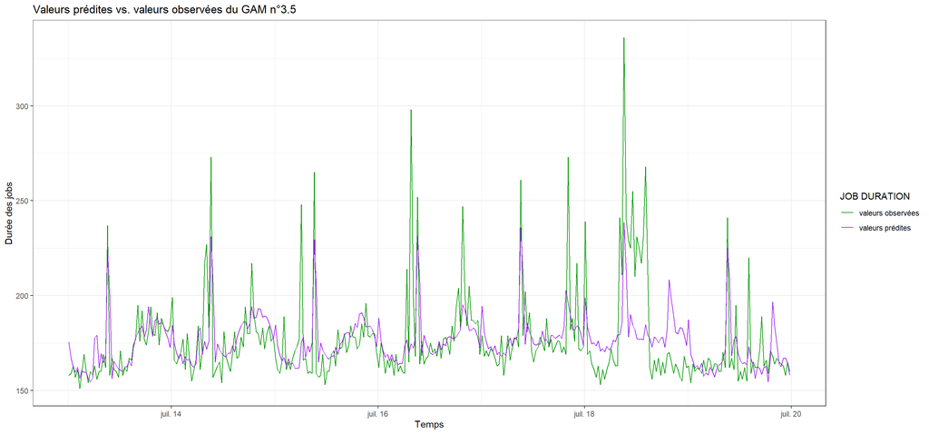

```r
fitted_ID2 <- gam3.5_ID2$fitted.values
prev_ID2 <- cbind(date_ID2, real_ID2, fitted_ID2)
prev_ID2 <- data.frame(prev_ID2)

ggplot(data=prev_ID2[222:557,])+
  geom_line(mapping=aes(y=real_ID2,x= START_TIME,color="valeurs observées")) +
  geom_line(mapping=aes(y=fitted_ID2,x= START_TIME,color="valeurs prédites")) +
  theme_bw() +
  scale_color_manual(values = c(
    'valeurs prédites' = "purple",
    'valeurs observées' = "#009900")) +
  labs(color = 'JOB DURATION', x = "Temps", y = "Durée des jobs",
       title = "Valeurs prédites vs. valeurs observées du GAM n°3.5")
```

- De la même manière que pour le modèle retenu pour la chronique une nous regardons la distribution des résidus. Nous observons alors comme visible ci-après, que certains résidus se distinguent des autres puisqu’ils correspondent à des temps de jobs importants (entre 300 et 400 secondes d’exécutions) mais prédits à la baisse par le modèle (entre 180 et 220 secondes). Ces quelques points sont facilement identifiables sur les 4 graphiques de diagnostic des résidus. Comme précédemment on peut observer une distribution Normal des résidus ou du moins qui s’en rapproche ce qui confirme notre hypothèse de distribution. Néanmoins les deux plots de droite montrent visuellement la présence d’hétéroscédasticité qu’il faudrait confirmer statistiquement si nous souhaitons être plus rigoureux. Cette fois-ci, les paramètres de lissages *k* semblent avoir été fixés correctement, car aucune des p-values est significatives.

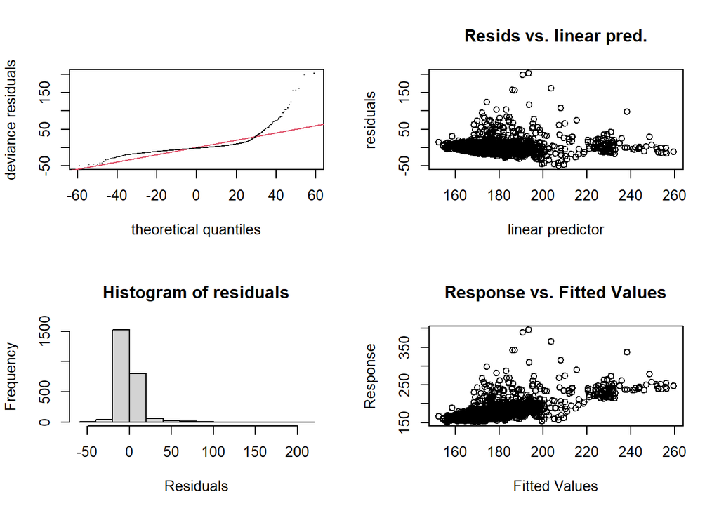

```r
# Résidus meilleur modèle
par(mfrow=c(2,2))
gam.check(gam3.5_ID2)
##
## Method: GCV   Optimizer: magic
## Smoothing parameter selection converged after 13 iterations.
## The RMS GCV score gradient at convergence was 0.0008146698 .
## The Hessian was positive definite.
## Model rank =  654 / 654
##
## Basis dimension (k) checking results. Low p-value (k-index<1) may
## indicate that k is too low, especially if edf is close to k'.
##
##                  k'   edf k-index p-value
## te(Day,Hour)  335.0  75.6    1.06    0.90
## te(Week,Hour) 276.0  44.4    0.99    0.41
## te(Week,Day)   42.0  28.2    0.98    0.32
```

- Concernant la concurvité on constate là encore qu’il n’y a pas de problème de multicolinéarité car les coefficients de concurvité observés prenent des valeurs entre 0.4 et 0.85 pour les 3 termes du modèle final.

```r
concurvity(gam3.5_ID2)
##                  para te(Day,Hour) te(Week,Hour) te(Week,Day)
## worst    1.631445e-12    1.0000000     1.0000000    1.0000000
## observed 1.631445e-12    0.8466615     0.4007018    0.5302344
## estimate 1.631445e-12    0.1565188     0.1952045    0.2851099
```

- Enfin, nous voyons l’évolution des durées des requêtes prédites par le GAM retenu, selon les variables ‘Day’ et ‘Hour’. Nous regardons leur effet car par rapport aux autres variables avec effet bivarié, ce sont celles qui ont le plus grand effet sur Y (cf. *summary* du modèle). Les temps des jobs sont plus importants en milieu de semaine, on retrouve toujours le pic de début de journée ainsi que celui en fin d’après-midi. Le pic important est une pattern commune aux temps des jobs de la chronique 1, sauf que l’un est à 5h41 tous les jours tandis que l’autre est à 9h09 - ce qui peut être lié à la période étudiée entre l’année scolaire et les périodes de grandes vacances.

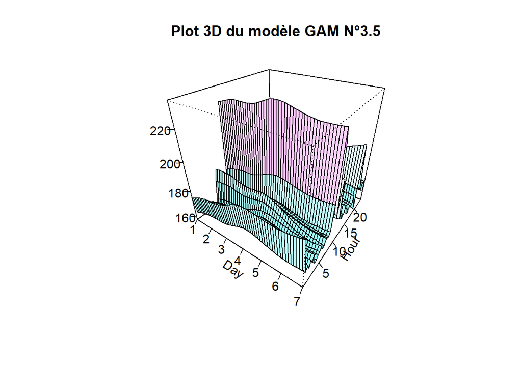

```r
# Plot 3D des valeurs de Y prédites par le GAM final
vis.gam(gam3.5_ID2, n.grid = 50, theta = 35, phi = 32, zlab = "",
        ticktype = "detailed", color = "cm", main = "Plot 3D du modèle GAM N°3.5")
```

###### Autocorrélation

De la même façon que pour l’ID1, nous pouvons observer la pertinence de rajouter à l’estimation des résidus du modèle GAM un processus autorégressif d’ordre 1. Le résultat du test Anova ci-dessous confirme encore une fois la nécéssité de prendre en compte le phénomène d’autocorrélation dans l’estimation de l’ID2 par le modèle GAM 3.5. Cela s’observe à travers un AIC et un BIC plus faibles pour le modèle gam3.5_ar1 et par le fait que cette différence soit significative car la p-value est très proche de 0.

```r
gam3.5_ar0 <- gamm(formula=JOB_DURATION ~ te(Day, Hour, k=c(7,48)) + te(Week, Hour, k=c(7,48)) + te(Week, Day, k=c(7,7)), data = df_ID2, method = "REML")

gam3.5_ar1 <- gamm(formula=JOB_DURATION ~ te(Day, Hour, k=c(7,48)) + te(Week, Hour, k=c(7,48)) + te(Week, Day, k=c(7,7)), data = df_ID2, correlation = corARMA(form = ~ 1|Week, p = 1), method = "REML")
anova(gam3.5_ar0$lme, gam3.5_ar1$lme)
##                Model df      AIC      BIC    logLik   Test  L.Ratio p-value
## gam3.5_ar0$lme     1 11 21555.53 21619.57 -10766.77
## gam3.5_ar1$lme     2 12 21484.09 21553.94 -10730.04 1 vs 2 73.44542  <.0001
```

Les plots ci-dessous nous montrent l’autocorélation partielle des résidus normalisés:

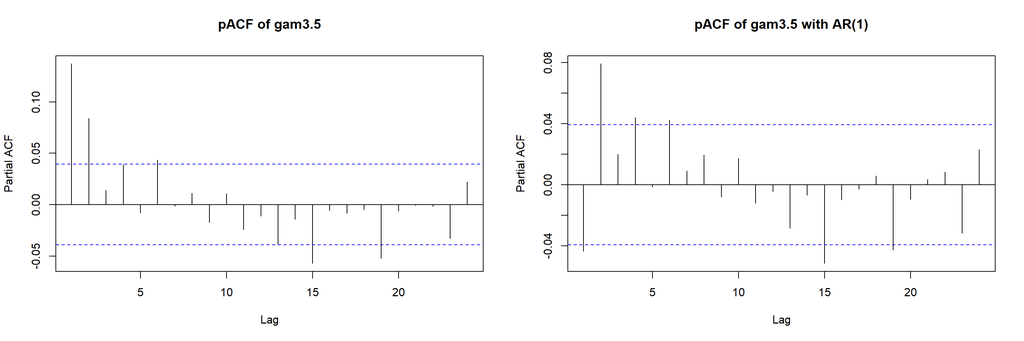

```r
layout(matrix(1:2, ncol = 2))
pacf(resid(gam3.5_ar0$lme, type = "normalized"), lag.max = 24, main = "pACF of gam3.5")
pacf(resid(gam3.5_ar1$lme, type = "normalized"), lag.max = 24, main = "pACF of gam3.5 with AR(1)")
```

La prise en compte de l’autocorrélation n’est pas très convaincante dans le graphique de droite. Il faudrait que les traits verticaux ne dépassent pas le seuil en poitillé bleu pour que les résidus soient considérés comme non-autocorrélés. La solution serait alors d’optimiser les paramètres du modèle autorégressif en augmentant l’ordre du comportement AR ou en ajoutant une partie MA au processus. Dans notre analyse, il nous a semblé nécéssaire d’expliquer comment traiter l’autocorrélation, mais n’avons pas optimisé la prise en compte de l’autoccorélation pour chaque chronique car le principe est le même et le temps d’exécution est très long.

#### ID 3

##### Modélisations

Enfin, c’est avec la chronique correspondant à la connection ID 3 que nous terminons l’analyse et la construction de modèles GAM. Comme observé en partie de visualisation des données, en plus des tendances au sein d’une journée nous observons pour cette chronique des tendances sur une semaine puisqu’on ne retrouve pas de pics de temps plus importants dans la journée le samedi. Nous incluons donc toutes les variables et construisons les modèles en les améliorant au fur et à mesure les prédictions, comme pour les estimations des chroniques 1 et 2.

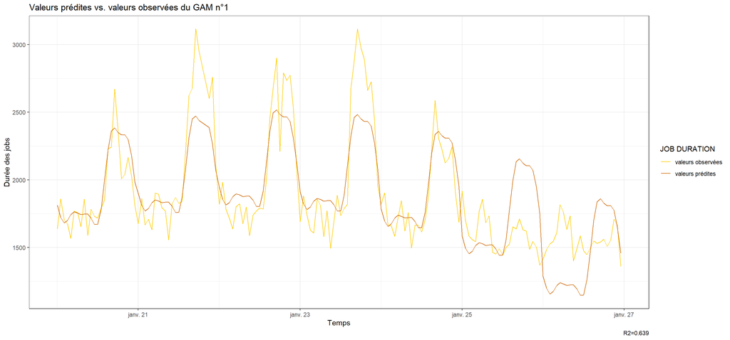

- Visuellement nous constatons la bonne qualité des prévisions réalisées à partir du dernier modèle ; les valeurs prédites suivent les évolutions principales des valeurs observées, la seule différence résidant dans quelques temps des jobs qui sont prédits pour la plupart plus faibles que la vraie valeur.

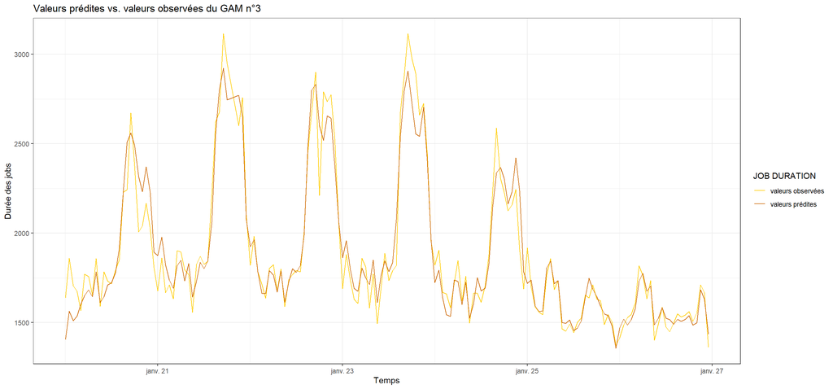

```r
fitted_ID3 <- gam3_ID3$fitted.values
prev_ID3 <- cbind(date_ID3, real_ID3, fitted_ID3)
prev_ID3 <- data.frame(prev_ID3)

ggplot(data=prev_ID3[280:445,])+
  geom_line(mapping=aes(y=real_ID3,x= START_TIME,color="valeurs observées")) +
  geom_line(mapping=aes(y=fitted_ID3,x= START_TIME,color="valeurs prédites")) +
  theme_bw() +
  scale_color_manual(values = c(
    'valeurs prédites' = "#CC6600",
    'valeurs observées' = "#FFCC00")) +
  labs(color = 'JOB DURATION', x = "Temps", y = "Durée des jobs",
       title = "Valeurs prédites vs. valeurs observées du GAM n°3")
```

##### Comparaison des modèles

###### Tableau

```r
# Calcul du MAPE pour chacun des modèles
MAPE_gam1_ID3 <- mean(abs((df_ID3$JOB_DURATION-gam1_ID3$fitted.values)/df_ID3$JOB_DURATION))
MAPE_gam2_ID3 <- mean(abs((df_ID3$JOB_DURATION-gam2_ID3$fitted.values)/df_ID3$JOB_DURATION))
MAPE_gam3_ID3 <- mean(abs((df_ID3$JOB_DURATION-gam3_ID3$fitted.values)/df_ID3$JOB_DURATION))

# --- Tableau récapitulatif des modèles éstimés ---
recap_modele_ID3 <- data.frame(GAM.1 = c("TAP_VERSION", "TAP_EXIT_STATUS", "s(Week)", "s(Day,k=1)", "s(Hour)", "4/5", 0.639, "-", round(gam1_ID3$aic,2), round(MAPE_gam1_ID3,4), "X"),
                               GAM.2 = c("TAP_EXIT_STATUS", "s(Week,k=10)", "s(Day,k=7)", "s(Hour,k=24)", "", "4/4", 0.681, 62305.42, round(gam2_ID3$aic,2), round(MAPE_gam2_ID3,4),"Ok"),
                               GAM.3.1 = c("TAP_EXIT_STATUS", "te(Week,Day,k=c(10,7))", "te(Hour,Day,k=c(24,7))", "te(Hour,Week,k=c(24,10))", "", "4/4", 0.885, 26049, round(gam3_ID3$aic,2), round(MAPE_gam3_ID3,4),"Ok"))

row.names(recap_modele_ID3) <- c("1er terme",  "2è terme",  "3è terme",  "4è terme", "5è terme", "Nombre de termes significatifs", "R2", "GCV", "AIC", "MAPE", "Validation")

kbl(recap_modele_ID3, caption="Tableau récapitulatif des modèles éstimés pour l'ID 3") %>% kable_classic(full_width = F, html_font = "Cambria") %>% column_spec(1, bold=T) %>% column_spec(4, color = 'green') %>% add_header_above(c(" " = 1, "Effets univariés seulement" = 2, "Effets bivariés" = 1), italic=T) %>% pack_rows("Termes inclus dans le modèle", 1, 5)
```

Tableau récapitulatif des modèles éstimés pour l’ID 3

Effets univariés seulement

Effets bivariés

GAM.1

GAM.2

GAM.3.1

**Termes inclus dans le modèle**

1er terme

TAP_VERSION

TAP_EXIT_STATUS

TAP_EXIT_STATUS

2è terme

TAP_EXIT_STATUS

s(Week,k=10)

te(Week,Day,k=c(10,7))

3è terme

s(Week)

s(Day,k=7)

te(Hour,Day,k=c(24,7))

4è terme

s(Day,k=1)

s(Hour,k=24)

te(Hour,Week,k=c(24,10))

5è terme

s(Hour)

Nombre de termes significatifs

4/5

4/4

4/4

R2

0.639

0.681

0.885

GCV

62305.42

26049

AIC

22149.91

21969.55

20544.62

MAPE

0.104

0.0969

0.0445

Validation

X

Ok

Ok

Comme visible sur la table ci-dessus nous avons estimé 3 modèles pour cette dernière sous-base de notre échantillon d’entraînement. Dans le premier nous incluons toutes les variables potentielles pour expliquer le temps des jobs de CONNCETION_ID=3 : il en ressort que ‘TAP_VERSION’ n’est pas significative donc nous l’excluons des estimations. Nous voyons aussi que contrairement aux ID 1 et 2, la qualité d’ajustement est directement élevée (63.9%) donc les variations doivent être plus régulières pour que le modèle les capte mieux. Nous améliorons cette première estimation dans une deuxième GAM où nous spécifions le nombre de splines ; de la même manière que les estimations précédentes nous fixons **k** au maximum c’est-à-dire au nombre de valeurs que prend chaque variable (dans la 3è sous-base il y a 10 semaines). Aussi, comme les modélisations précédentes, le fait de spécifier les types de splines n’améliore pas les estimations voire les diminue (très légèrement). En outre, dans un dernier modèle nous ajoutons les effets bivariés avec les 3 combinaisons possibles des variables explicatives et atteigons alors un $R^2$ de 0.885, soit le meilleur que nous ayons pu trouver jusqu’ici. Regardons plus précisément les caractéristiques de ce modèle n°3 que nous gardons comme modèle final.

###### Résidus

- Le diagnostic montre cette fois des résidus beaucoup mieux distribués que pour les modèles des ID 1 et 2. Leur distribution visible sur l’histogramme s’apparente davantage à celle d’une loi normale, sur le graphique “Resids vs. linear pred.” les valeurs sont plus groupées autour de 0 et sur le graphique des valeurs prédites et observées elles sont davantage situées sur la bissectrice. Les résidus de ce troisième modèle sont donc bien meilleurs que les précédents. Tout comme l’ID2, les paramètres de lissages *k* sont suffisamment grands, car aucune des p-values est significatives.

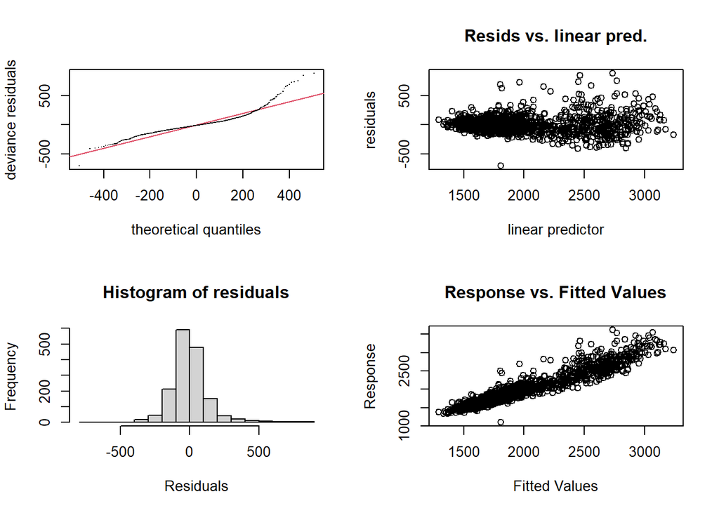

```r
# Résidus meilleur modèle
par(mfrow=c(2,2))
gam.check(gam3_ID3)
##
## Method: GCV   Optimizer: magic
## Smoothing parameter selection converged after 18 iterations.
## The RMS GCV score gradient at convergence was 0.001604292 .
## The Hessian was positive definite.
## Model rank =  439 / 439
##
## Basis dimension (k) checking results. Low p-value (k-index<1) may
## indicate that k is too low, especially if edf is close to k'.
##
##                  k'   edf k-index p-value
## te(Week,Day)   69.0  62.1    1.00    0.50
## te(Hour,Day)  161.0 134.6    1.04    0.95
## te(Hour,Week) 207.0  54.1    0.99    0.36
```

- Il n’y a pas non plus de problème de colinéarité entre les termes de l’estimation puisque les coefficients de concurvité se situent pour ce modèle entre 0.7 et 0.98.

```
##               para te(Week,Day) te(Hour,Day) te(Hour,Week)
## worst    0.3631692 1.841721e+28    0.9993514     0.9987963
## observed 0.3631692 9.773962e-01    0.8631211     0.7027251
## estimate 0.3631692 2.204587e-01    0.1704511     0.1422472
```

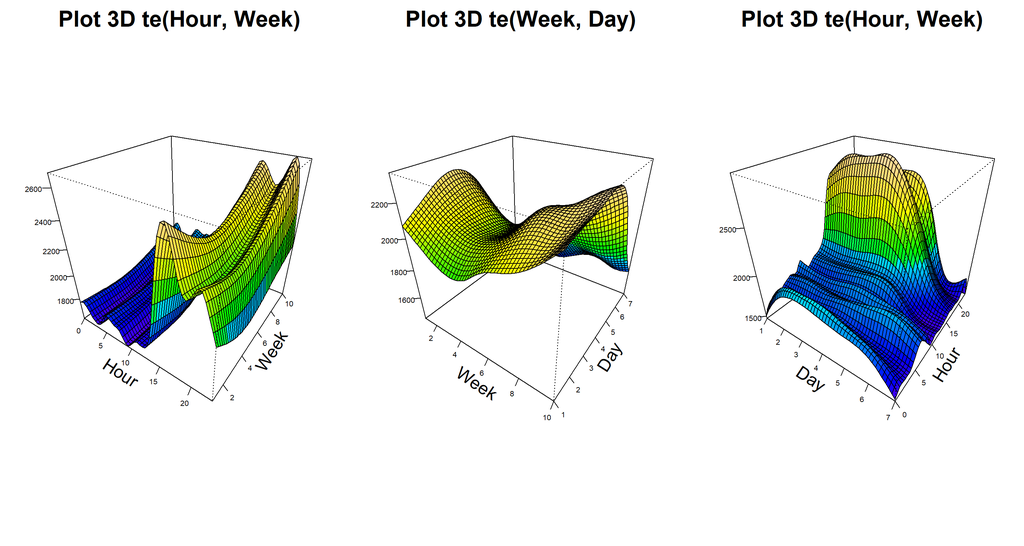

```r
# Plot 3D des valeurs de Y prédites par le GAM final
    # Variables
gam3.1_ID3 <- gam(formula=JOB_DURATION ~ te(Hour,Week,k=c(24,10)), data = df_ID3)
gam3.2_ID3 <- gam(formula=JOB_DURATION ~ te(Week,Day,k=c(10,7)), data = df_ID3)
gam3.3_ID3 <- gam(formula=JOB_DURATION ~ te(Day,Hour,k=c(7,24)), data = df_ID3)

par(mfrow=c(1,3))
vis.gam(gam3.1_ID3, n.grid = 50, theta = 35, phi = 32, zlab = "", ticktype = "detailed", color = "topo", main = "Plot 3D te(Hour, Week)", cex.main=3, cex.lab=2.3)
vis.gam(gam3.2_ID3, n.grid = 50, theta = 35, phi = 32, zlab = "", ticktype = "detailed", color = "topo", main = "Plot 3D te(Week, Day)", cex.main=3, cex.lab=2.3)
vis.gam(gam3.3_ID3, n.grid = 50, theta = 35, phi = 32, zlab = "", ticktype = "detailed", color = "topo", main = "Plot 3D te(Hour, Week)", cex.main=3, cex.lab=2.3)
```

Pour conclure nous pouvons voir à la fois par le diagnostique des réisuds, les différents graphiques et les taux d’erreur que le modèle estimé pour cette troisième sous-base est le plus précis que nous ayons pu construire jusqu’ici.

###### Autocorrélation

Encore un fois nous pouvons observer les critères d’information de l’AIC et du BIC plus faibles significativement pour le modèle gam3_ar1, c’est à dire où est prise en compte l’autocorrélation des résidus.

```r
gam3_ar0 <- gamm(formula=JOB_DURATION ~ TAP_EXIT_STATUS + te(Week,Day,k=c(10,7)) + te(Hour,Day,k=c(24,7)) + te(Hour,Week,k=c(24,10)), data = df_ID3, method = "REML")

gam3_ar1 <- gamm(formula=JOB_DURATION ~ TAP_EXIT_STATUS + te(Week,Day,k=c(10,7)) + te(Hour,Day,k=c(24,7)) + te(Hour,Week,k=c(24,10)), data = df_ID3,correlation = corARMA(form = ~ 1|Week, p = 1), method = "REML")

anova(gam3_ar0$lme, gam3_ar1$lme)
##              Model df      AIC      BIC    logLik   Test  L.Ratio p-value
## gam3_ar0$lme     1 12 20989.41 21053.78 -10482.71
## gam3_ar1$lme     2 13 20726.02 20795.75 -10350.01 1 vs 2 265.3959  <.0001
```

Les plots ci-dessous nous montrent l’autocorélation partielle des résidus normalisés :

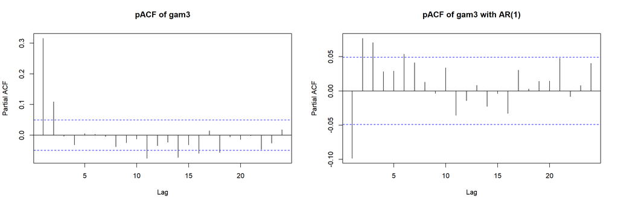

```r
layout(matrix(1:2, ncol = 2))
pacf(resid(gam3_ar0$lme, type = "normalized"), lag.max = 24, main = "pACF of gam3")
pacf(resid(gam3_ar1$lme, type = "normalized"), lag.max = 24, main = "pACF of gam3 with AR(1)")
```

Pour la chronique 3, nous pouvons observer visuellement une amélioration des résidus lors de la prise en compte de l’autocorrélation par un AR d’ordre 1. En effet les autocorrélations partielles des résidus normalisés sont majoritairement comprises entre les lignes en pointillé. Malgré cela, il serait tout de même judicieux d’optimiser l’ordre du processus AR pour une meilleure prise en compte de ce phénomène comme nous l’avons développé dans la chronique 1.

### 2.3 Résumé visuel des modèles retenus

Pour terminer cette partie de recherche et d’optimisation des modèles additifs généralisés, nous regardons les graphiques d’évolution des valeurs observées et prédites par chaque modèle retenu.

```r
#---- ID1 ----
data(prev_ID1)
amTimeSeries(prev_ID1,"START_TIME", c("real_ID1", "fitted_ID1"), color=c('red', 'blue'), main = "Real vs fitted ID1")
```

[interactive chart not shown]

```r
#---- ID2 ----
data(prev_ID2)
amTimeSeries(prev_ID2,"START_TIME", c("real_ID2", "fitted_ID2"), color=c("#009900", "purple"), main = "Real vs fitted ID2")
```

[interactive chart not shown]

```r
#---- ID3 ----
data(prev_ID3)
amTimeSeries(prev_ID3,"START_TIME", c("real_ID3", "fitted_ID3"), color=c("#FFCC00", "#CC6600"), main = "Real vs fitted ID3")
```

[interactive chart not shown]

## 3-Soumission des prévisions et conclusion

Maintenant que nous avons construit les modèles les plus précis en termes de prévisions nous allons soumettre des prédictions pour la compétition kaggle. Pour cela nous devons mettre la base *‘test’* au même format que la base ‘*train*’ pour pouvoir appliquer les modèles construits à partir de cette dernière. La base test contient 1700 observations et 5 variables comme précisé en introduction : notre objectif est donc, à partir des données disponibles, de prédire le temps d’éxécution des jobs Stitch.

En reprenant les commandes pour la base d’apprentissage, nous séparons la base test en 3 sous-échantillons à partir de la CONNECTION ID, puis nous créons les variables de semaine, jours et heures pour chacune d’entre elles grâce à la variable ‘START_TIME’. Enfin, nous passons les variables créées au format numérique pour pouvoir appliquer librement les modèles additifs généralisés.

Nous commençons par appliquer le quatrième modèle sélectionné pour la sous-base de la chronique 1, grâce à la fonction **predict.gam()** contenue elle aussi dans le package `mgcv` sous R. Nous réalisons ainsi les prévisions pour les 3 base de données test en créant chaque fois une colonne ‘Predicted’ dans l’échantillon concernée, puis nous supprimerons toutes les variables autres que celle-ci et l’ID, pour retrouver la forme du fichier *sample_solution* que nous importerons sur Kaggle pour voir les résultats de notre estimation, après avoir rassemblé de nouveau les 3 sous-bases.

Les lignes de code suivantes ont permis un tel processus :

```r
#------- ID 1 ----------
# On fait les prévisions pour la base test de la chronique 1 avec le modèle sélectionné pour cet ID
  #test_ID1$Predicted <- predict.gam(gam4_ID1, test_ID1)  #ne fonctionne pas car les versions TAP sont différentes, nous retirons cette variable et commencons une nouvelle fois

# On reestime le modèle 4 en enlevant 'TAP_VERSION'
gam4_ID1 <- gam(JOB_DURATION ~ s(Day, k=7, bs="cp") + te(Week, Hour, k=c(30,24), bs = c("ps", "cc")), data = df_ID1)
  # on fait les prévisions
test_ID1$Predicted <- predict.gam(gam4_ID1, test_ID1)


#------- ID 2 ----------
test_ID2$Predicted <- predict.gam(gam3.5_ID2, test_ID2)


#------- ID 3 ----------
test_ID3$Predicted <- predict.gam(gam3_ID3, test_ID3)


# On remet les bases au format du fichier 'sample_solution'
    # on retire toutes les autres variables
test_ID1 <- test_ID1[,-c(1:4,6:8)]
test_ID2 <- test_ID2[,-c(1:4,6:8)]
test_ID3 <- test_ID3[,-c(1:4,6:8)]

    # on regroupe les 3 bases un 1 df à soumettre sur kaggle
sample_solution <- rbind(test_ID1, test_ID2, test_ID3)

    # on exporte ces 2 df au format csv
rio::export(sample_solution, "./sample_solution.csv")
```

Après soumission, nous avons obtenons un taux d’erreur MAPE de 14.28%. Notre étude est donc terminée et les prévisions du temps d’éxecution des requêtes Stitch sont satisfaisantes.